# Week #1 Summary

# Analysis of Similarities (ANOSIM)

Analysis of similarities (ANOSIM) provides a way to test statistically whether there is a significant difference between two or more groups of sampling units.

Function 'anosim' in package 'vegan' is used.

```r
library(vegan)

# make a dataframe for just the groupings of sites
data.grp <- data[c(1, 34:35)]

# test differences among periods
anosim(counts, data.grp$Period, permutations = 999, distance = "bray")
```

```
##
## Call:
## anosim(dat = counts, grouping = data.grp$Period, permutations = 999,      distance = "bray")
## Dissimilarity: bray
##
## ANOSIM statistic R: 0.423
##       Significance: 0.005
##
## Based on  999  permutations
```

```r
# test differences between regions
anosim(counts, data.grp$Region, permutations = 999, distance = "bray")
```

```
##
## Call:
## anosim(dat = counts, grouping = data.grp$Region, permutations = 999,      distance = "bray")
## Dissimilarity: bray
##
## ANOSIM statistic R: 0.643
##       Significance: 0.002
##
## Based on  999  permutations
```

## Assigned Papers:

Manly, B.F. 1996. The statistical analysis of artefacts in graves: presence and absence data. Journal of Archaeological Science 23(4): 473-484.

Stutz, A.J., and G.F. Estabrook. 2004. Computationally intensive multivariate statistics and relative frequency distribution in archaeology (with an application to the Early Epipaleolithic of the Levant) Journal of Archaeological Science 31:1643-1658.

## Additional references:

on Non-metric multidimensional scaling: Kruskal, J.B. 1964. Nonmetric multidimensional scaling: A numerical method. Psychometrika 29(2):115-129.

On ANOSIM: Chapman, M.G., and A.J. Underwood. 1999. Ecological patterns in multivariate assemblages: information and interpretation of negative values in ANOSIM tests. Marine ecology progress series 180:257-265.

# Week 12 Summary

Note below adapted from Sam, Emily R and Rome Note that the Anderson et al. paper is kind of a short version of their book on the same subject

Thre traditional approach to model selection now is the Akaike Information Criterion (AIC) but the Anderson et al. paper suggests it my not be the best way to select a model

The idea of models is that you are trying to fit complex “real world” mechanisms to simplistic explanations. The less parameters you have, the more simplistic your model is. But whaen your model gets too complex, you could end up just fitting noise, which is meaningless. Additionally, when adding parameters, there is a tradeoff between bias and variance. This is why AIC weighs the likelihoods of models with penalty costs to the number of parameters they have.

AIc holds an advantage over stepwise regression because AIC can compare any model using the same data, not just nested ones.

## Background and Math - Thanks to Emily R for these notes

As described in the Anderson et al. paper, traditional methods of model selection have a lot of problems. They advocate an alternative approach using Akaike's Information Criterion,

\[ AIC = -2 \log \mathcal L + 2 k \]

where \( \mathcal L \) is the model's likelihood and \( k \) is the number of fitted parameters in the model. The absolute value of \( AIC \) is not informative, but within a set of models–*provided they are fit to the same data*–the model with the *lowest* \( AIC \) is theoretically the best, in terms of optimizing the bias-variance tradeoff.

The corrected version for small sample sizes (\( AICc \)) adds another term on the end: \[ AICc = -2 \log \mathcal L + 2 k + \frac{2k(k+1)}{n - k - 1} \] Here, \( n \) is the number of data points. The original \( AIC \) tends to be too liberal when sample sizes are small, encouraging overfitting. The extra penalty term in \( AIC_c \) corrects for this. As \( n \) gets much larger than the number of parameters, the two versions converge, so there's no reason not to use \( AICc \) all the time. There a bunch of criteria like this, similar to or derived from \( AIC \), and all work more or less the same way. For generality, I'll use “AIC” as a catch-all term here.

Again, the absolute value of \( AIC \) is meaningless–it is the relative values within a set of candidate models that is important. As such, we are usually more interested in the difference between a given model's \( AIC \) value and the lowest value in the set:

\[ \Delta_i = AIC_i - AIC_{min} \]

This allows us to rank the models from best to worst. As a rule of thumb, models with delta-AIC values less than 2 or 3 units apart have a pretty similar level of support. If several models are close to the best one, we can't really be confident that the model ranking would remain the same if we were able to collect a new data set and do the model-selection procedure again.

To get at this uncertaintly more rigorously, we can calculate the “Akaike weight” for each model: \[ w_i = \frac{\exp \left(-\Delta_i/2 \right)}{\sum_{r=1}^{R} \exp \left( -\Delta_r / 2 \right)} \] The weights add up to 1, and represent the probability that each model would be chosen as the best if the model selection procedure were run again on a new dataset generated by the same underlying process.

It is also possible to obtain similar results by boostrapping a dataset and fitting the models to the simulated data, measuring how many times a model is identified as the best on boostrapped data, empirically calculating the probability of a model to be selected.

## Data and coding

All of the AIC-based procedures are conveniently available in the `AICcmodavg` package.

```r
require(AICcmodavg)
require(RCurl)
```

We will be using some data from a simulated survey of an imaginary mountain valley.

[figure not shown]

You have spent an imaginary summer hiking all over the place, sampling random locations. At each location, you have recorded whether the bird of interest was present, along with the percent cover of each of three plant species. The high elevations are mostly bare rock and the valley floor is mostly farmland; there are variables coding for these types of cover as well.

```r
url.bhab <- getURL("https://raw.githubusercontent.com/PermuteSeminar/PermuteSeminar-2014/master/Week-12/bird_habitat.csv")

bhab <- read.csv(text = url.bhab)

getAICtab <- function(bhab) {
    mod1 <- glm(bird.present ~ elevation, bhab, family = binomial)
    mod2 <- glm(bird.present ~ farm, bhab, family = binomial)
    mod3 <- glm(bird.present ~ northing + easting, bhab, family = binomial)
    tab <- aictab(list(mod1, mod2, mod3), modnames = c("Elevation", "Farm",
        "Position"))
    return(as.character(tab[1, 1]))
}

vec <- c()
for (i in 1:500) {
    bootROW <- sample(1:nrow(bhab), nrow(bhab), replace = T)
    vec[i] <- getAICtab(bhab[bootROW, ])
}

table(vec)
```

```
## vec
## Elevation      Farm  Position
##        12       357       131
```

The code was Jon's solution, The 'vec' table returns the number of times each model was the best supported out of 500 boostraps, allowing to select the best model.

## Assigned Reading:

Anderson, D. R., K. P. Burnham and W. L. Thompson. 2000. Null hypothesis testing: problems, prevalence and an alternative. Jour. Wildlife Management 64(4): 912-923.

Driscoll, M. J. L., T. Donovan, R. Mickey, A. Howard and K. K. Fleming. 2005. Determinants of wood thrush nest success: a multi-scale, model selection approach. Jour. Wildlife Management 69(2): 699-709.

Shmueli, G. 2010. To explain or to predict ? Stat. Sci. 25(3): 289-310.

Week #13 Summary

# Based on data from Svoboda et al. 2014

This week we explored questions similar to those posed in week 11. We compared the communities of Desmids (a type of algae) in wetland communities.

Our primary goal was to test for spatial autocorrelation between the community composition of sites.

This autocorelation can be tested using the test statistic R given in Clark 1993.

\[ R= \frac{(\bar{r}_{b} - \bar{r}_{w})}{M/2} \]

R is calculated based on the distances between points in a Multi Dimentional Scaling (MDS) analysis. There are several problems with using the MDS distances in a test statistic however. Different numbers of dimentions in the MDS would result in different values for the test statistic, even though the number of dimensions is somewhat arbitrary. These problems are solved by using the rank similarities between samples. More similar samples are ranked higher than less similar samples. Thus, in the test statistic R, \( \bar{r}_{b} \) gives the average rank of the differences between sites while \( \bar{r}_{w} \) gives the average rank of differences within sites. M is simply a constant based on sample size that scales R so that it does not exceed the range -1:1.

# Excercise

The data provided were transformed in several different ways, and different analyses may require the data in different forms from what I will be using here, but the files I will be using are pre-transformed and uploaded on GitHub.

```r
require(RCurl)
require(vegan)
require(ggplot2)
options(RCurlOptions = list(cainfo = system.file("CurlSSL", "cacert.pem", package = "RCurl")))

raw <- getURL("https://raw.githubusercontent.com/PermuteSeminar/PermuteSeminar-2014/master/Week-13/Svoboda_transpose.csv")
data <- read.csv(text = raw, row.names = 1)
raw.2 <- getURL("https://raw.githubusercontent.com/PermuteSeminar/PermuteSeminar-2014/master/Week-13/EJR_siteinfo.csv")
Groups <- read.csv(text = raw.2)
```

First we can visualize the data in several different ways

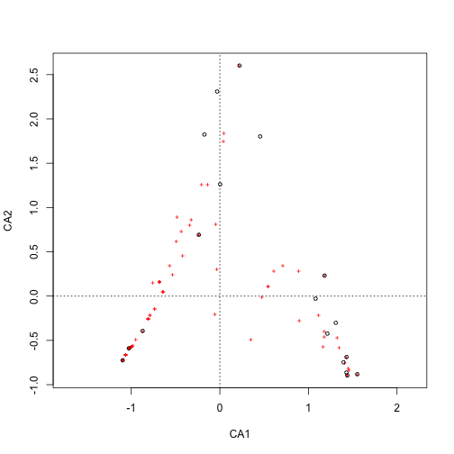

```r
cca.data <- cca(data)
plot(cca.data)
```

```r
# The crosses are species and the circles are sites


MDS.data <- metaMDS(data, distance = "bray", trymax = 50)
```

```
## ... procrustes: rmse 0.000278  max resid 0.0008912
## *** Solution reached
```

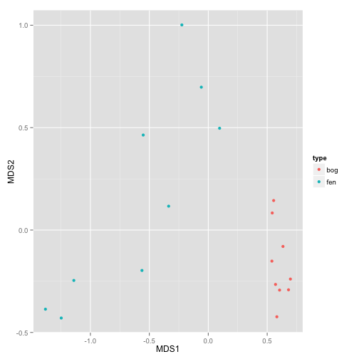

```r
points <- as.data.frame(MDS.data$points)
points <- cbind(points, type = Groups$Type)
ggplot(points, aes(x = MDS1, y = MDS2, col = type)) + geom_point()
```

```r
# this is color-coded for bogs vs. fens, you could color code the pools as
# well
```

Now that we have visualized the data it is pretty clear that there is a difference between the Bog and Fen sites. To statistically test the differences between the two habitats or the sites within these habitats we need to calculate R, and then permute the similarities in order to create a bootstrap distribution to test the significance of our test statistic. We could do this all by hand, but luckily the vegan package in R can do it all for us. The function anosim both uses R as its test statistic, and it provides a p value via permutation.

So to compare our sites all we have to do is the following.

```r
# Difference between fen and bog
anosim(data, Groups$Type, permutations = 999, distance = "bray")
```

```
##
## Call:
## anosim(dat = data, grouping = Groups$Type, permutations = 999,      distance = "bray")
## Dissimilarity: bray
##
## ANOSIM statistic R: 0.749
##       Significance: 0.001
##
## Based on  999  permutations
```

```r
# Differences among fens
anosim(data[1:9, ], Groups[1:9, ]$Site, permutations = 999, distance = "bray")
```

```
##
## Call:
## anosim(dat = data[1:9, ], grouping = Groups[1:9, ]$Site, permutations = 999,      distance = "bray")
## Dissimilarity: bray
##
## ANOSIM statistic R: 0.918
##       Significance: 0.005
##
## Based on  999  permutations
```

```r
# Differences among bogs
anosim(data[10:18, ], Groups[10:18, ]$Site, permutations = 999, distance = "bray")
```

```
##
## Call:
## anosim(dat = data[10:18, ], grouping = Groups[10:18, ]$Site,      permutations = 999, distance = "bray")
## Dissimilarity: bray
##
## ANOSIM statistic R: 0.37
##       Significance: 0.061
##
## Based on  999  permutations
```

## Assigned Paper:

Svoboda, P., J. Kulichová, and J. Št’astný. 2013. Spatial and temporal community structure of desmids on a small spatial scale. Hydrobiologia 722:291–303.

## Additional Paper:

Clarke, K. R. 1993. Non‐parametric multivariate analyses of changes in community structure. Australian journal of ecology 18:117–143.

# Week #14 Summary

## Overview

Phylogenetic trees are a useful tool in the analysis of patterns in ecological communities. Phylogenetic diversity is a potential metric that can be used to describe the structure of a community, in the same way as other measures of diversity (such as species richness, Shannon diversity, and so on). If we assume that traits are generally conserved in the evolution of a lineage, we should expect a positive relationship between the phylogenetic relatedness of a pair of species and the similarity of those species in ecological or life history traits. Therefore, the phylogenetic structure of a community provides some understanding of the ecological processes that played a role in the organization of that community. For instance, 1) if species are more related than one would expect due to chance, perhaps some environmental variable is limiting which species can be present in that community by requiring a certain suite of traits; 2) if species are less related than expected due to chance, we might suspect that competition between similar species played a role in community assembly. To perform this analysis, we need to determine what sort of phylogenetic structure might be expected in a community due to chance alone by creating a null distribution of phylogentic relatedness.

## Exercise

We will be testing the phylogenetic structure of a series of hummingbird communities. To do this, we will use the package 'picante', which provides a series of functions for phylogenetic community analysis, as well as 'vegan', which provides various tools for community ecology. Our goal is to generate null models of phylogenetic community structure, and determine if each community is significantly overdispersed or clustered relative to that null. (Overdispersed = species in the community are less related to one another than you would expect by chance; clustered = species in the community are more related to one another than you would expect by chance.)

## Code

Load libraries

```r
require(picante)
```

```r
require(vegan)
require(ggplot2)
require(RCurl)
require(reshape)
```

Read in the data

```r
options(RCurlOptions = list(cainfo = system.file("CurlSSL", "cacert.pem", package = "RCurl")))

# Site by species matrix of hummingbird communities; setting row.names=1
# will make some things easier later
raw1 <- getURL("https://raw.githubusercontent.com/PermuteSeminar/PermuteSeminar-2014/master/Week%2014/SiteXspp.csv")
sitesp <- read.csv(text = raw1, row.names = 1)

# Hummingbird phylogeny - Newick/parenthetic format (.tre)
raw2 <- getURL("https://raw.githubusercontent.com/PermuteSeminar/PermuteSeminar-2014/master/Week%2014/newtree.tre")
tree <- read.tree(text = raw2)
```

Calculate the cophenetic distance matrix of the tree (a matrix of pairwise distances between each pair of species in the tree, as defined by the branch lengths in the tree)

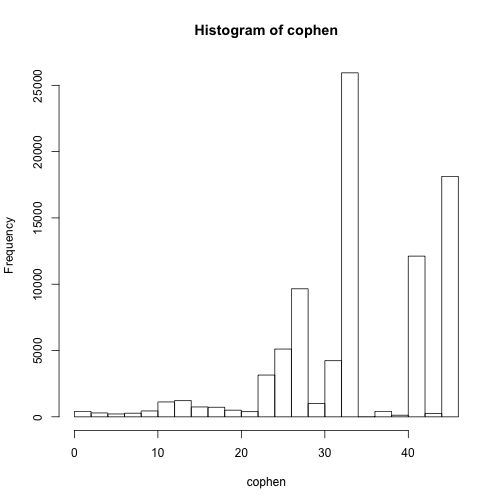

```r
cophen <- cophenetic(tree)
hist(cophen)
```

We need to check that the species in our tree and the species in the site by species matrix match, because we'll need to remove any species in a community that aren't found in the tree from our analyses.

```r
# Counts how many species in the site by species matrix aren't in the tree
sum(!colnames(sitesp[, 2:ncol(sitesp)]) %in% tree$tip.label)
```

```
## [1] 40
```

```r
# Counts how many species in the tree aren't in the matrix (we don't need
# to know this, but let's look at it anyway)
sum(!tree$tip.label %in% colnames(sitesp[, 2:ncol(sitesp)]))
```

```
## [1] 202
```

There are 40 species in the species matrix that aren't in our tree. We can subsample the site by species matrix to use only those species that are included in our phylogeny.

Calculate the mean phylogenetic distance (MPD; our test statistic) for each site, and make a data frame that lists that MPD for each site

```r
mpd <- mpd(sitesp[, colnames(sitesp) %in% tree$tip.label], cophen)
MPDtable <- as.data.frame(mpd)
row.names(MPDtable) <- row.names(sitesp)
```

We want to test the observed MPD for each site against a null expectation of community MPD given our species pool. We will do this by randomizing the site by species matrix and resampling MPD 100 times. The package 'vegan' provides a number of methods for randomization within the function 'commsimulator'. We will use three:

r00 = Maintains the number of presences, but refills them in the matrix completely randomly (not maintaining row or column sums) r0 = Maintains row sums, but not column sums c0 = Maintains column sums, but not row sums

This will generate the null models against which we can test the observed MPD statistic for each site.

```r
# Making tables to store randomization output
MPD_r00 <- MPDtable
MPD_r0 <- MPDtable
MPD_c0 <- MPDtable

# r00
for (i in 1:100) {
    randcom = commsimulator(sitesp, "r00")
    randmpd = mpd(randcom[, colnames(randcom) %in% tree$tip.label], cophen)
    MPD_r00 = cbind(MPD_r00, randmpd)
}

# r0
for (i in 1:100) {
    randcom = commsimulator(sitesp, "r0")
    randmpd = mpd(randcom[, colnames(randcom) %in% tree$tip.label], cophen)
    MPD_r0 = cbind(MPD_r0, randmpd)
}

# c0
for (i in 1:100) {
    randcom = commsimulator(sitesp, "c0")
    randmpd = mpd(randcom[, colnames(randcom) %in% tree$tip.label], cophen)
    MPD_c0 = cbind(MPD_c0, randmpd)
}
```

Let's just look at the plot for the site 'Acacias', since there are too many sites to be worth looking at individually for our purposes.

```r
# This is the most circuitous plotting code ever and I sincerely
# apologize, but it works!
Acacias_r00 <- melt(MPD_r00[5])
```

```
## Using  as id variables
```

```r
Acacias_r0 <- melt(MPD_r0[5])
```

```
## Using  as id variables
```

```r
Acacias_c0 <- melt(MPD_c0[5])
```

```
## Using  as id variables
```

```r
Acacias <- cbind(Acacias_r00, Acacias_r0$value, Acacias_c0$value)
colnames(Acacias) <- c("MPD", "r00", "r0", "c0")

Acacias2 <- melt(Acacias[2:4])
```

```
## Using  as id variables
```

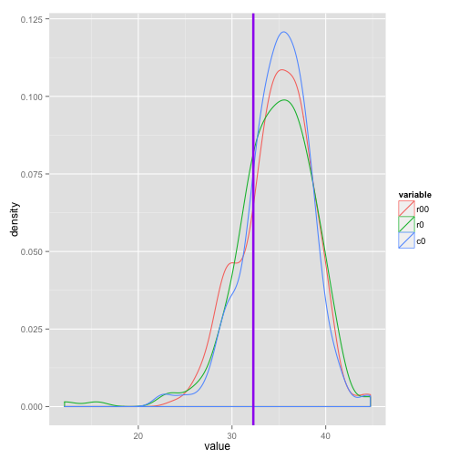

```r
ggplot(Acacias2, aes(x = value, color = variable)) + geom_density() + geom_vline(xintercept = MPDtable[5,
    1], color = "purple", size = 1.2)
```

This shows the three null distributions (r00, r0 and c0) of the test statistic MPD for the Acacias site - note that our choices about whether or not to fix row or column sums when we randomize changes the shape of the null model! The vertical bar (purple) plots the observed MPD for the Acacias site. As such, caution needs to be taken when comparing the observed MPD to the null model selected.

## Assigned Readings:

Webb, C.O. 2000. Exploring the phylogenetic structure of ecological communities: An example for rain forest trees. The American Naturalist 156: 145-155

Gotelli, N.J. and G.L. Entsminger. 2001. Swap and fill algorithms in null model analysis: rethinking the knight's tour. Oecologia 129:281-291

Gotelli, N.J. and G.L. Entsminger. 2003. Swap algorithms in null model analysis. Ecology 84:532-535

Miklós, I. and J. Podani. Randomization of Presence-Absence Matrices: Comments and New Algorithms. Ecology 85:86-92